# R Notebook

COMO PRIMERA MEDIDA, ISNTALAMOS LAS LIBRERÍAS QUE NECESITAMOS

```r
install.packages("caret")
install.packages("MASS")
install.packages("tidyverse")
library(tidyverse)
library(MASS)
library(caret)
```

Descargamos el dataset a trabajar que consiste en el listado de los jugadores de los equipos de la primera división del fútbol colombiano

| full_name | age | birthday | birthday_GMT | league | season | position | Current.Club | minutes_played_overall | minutes_played_home | minutes_played_away | nationality | appearances_overall | appearances_home | appearances_away | goals_overall | goals_home | goals_away | assists_overall | assists_home | assists_away | penalty_goals | penalty_misses | clean_sheets_overall | clean_sheets_home | clean_sheets_away | conceded_overall | conceded_home | conceded_away | yellow_cards_overall | … |
| --- | --- | --- | --- | --- | --- | --- | --- | --- | --- | --- | --- | --- | --- | --- | --- | --- | --- | --- | --- | --- | --- | --- | --- | --- | --- | --- | --- | --- | --- | --- |
| Adam Ozeri | 24 | 889228800 | 1998/03/07 | Categoria Primera A | 2022 | Midfielder | Patriotas Boyac\xe1 | 37 | 16 | 21 | USA | 2 | 1 | 1 | 0 | 0 | 0 | 0 | 0 | 0 | 0 | 0 | 0 | 0 | 0 | 0 | 0 | 0 | 2 | … |
| Adri\xe1n Arregui | 29 | 713577600 | 1992/08/12 | Categoria Primera A | 2022 | Defender | Independiente Medell\xedn | 1887 | 897 | 990 | Argentina | 22 | 11 | 11 | 3 | 2 | 1 | 2 | 1 | 1 | 0 | 0 | 10 | 8 | 2 | 15 | 2 | 13 | 6 | … |
| Adri\xe1n Estacio | 24 | 893030400 | 1998/04/20 | Categoria Primera A | 2022 | Midfielder | Deportivo Pasto | 536 | 294 | 242 | Colombia | 11 | 5 | 6 | 2 | 2 | 0 | 0 | 0 | 0 | 0 | 0 | 3 | 1 | 2 | 5 | 3 | 2 | 2 | … |
| Agust\xedn Auzmendi | 25 | 854755200 | 1997/02/01 | Categoria Primera A | 2022 | Forward | Jaguares de C\xf3rdoba | 73 | 22 | 51 | Argentina | 4 | 2 | 2 | 0 | 0 | 0 | 0 | 0 | 0 | 0 | 0 | 0 | 0 | 0 | 3 | 1 | 2 | 0 | … |
| Agust\xedn Cano Lotero | 20 | 991958400 | 2001/06/08 | Categoria Primera A | 2022 | Midfielder | Atl\xe9tico Nacional | 30 | 0 | 30 | Colombia | 1 | 0 | 1 | 0 | 0 | 0 | 0 | 0 | 0 | 0 | 0 | 0 | 0 | 0 | 1 | 0 | 1 | 0 | … |
| Agust\xedn Vuletich | 30 | 689126400 | 1991/11/03 | Categoria Primera A | 2022 | Forward | Deportivo Cali | 520 | 280 | 240 | Argentina | 8 | 5 | 3 | 0 | 0 | 0 | 0 | 0 | 0 | 0 | 1 | 1 | 0 | 1 | 4 | 2 | 2 | 2 | … |
| Alain Yuli\xe1n Guerrero Acosta | 20 | 998784000 | 2001/08/26 | Categoria Primera A | 2022 | Defender | Uni\xf3n Magdalena | 66 | 2 | 64 | Colombia | 3 | 1 | 2 | 0 | 0 | 0 | 0 | 0 | 0 | 0 | 0 | 1 | 0 | 1 | 0 | 0 | 0 | 0 | … |
| Aldair Alejandro Quintana Rojas | 27 | 773884800 | 1994/07/11 | Categoria Primera A | 2022 | Goalkeeper | Atl\xe9tico Nacional | 406 | 90 | 316 | Colombia | 5 | 1 | 4 | 0 | 0 | 0 | 0 | 0 | 0 | 0 | 0 | 0 | 0 | 0 | 8 | 1 | 7 | 0 | … |
| Aldair Yesid Guti\xe9rrez Toncel | 23 | 898041600 | 1998/06/17 | Categoria Primera A | 2022 | Defender | Deportivo Cali | 1073 | 536 | 537 | Colombia | 16 | 8 | 8 | 0 | 0 | 0 | 0 | 0 | 0 | 0 | 0 | 4 | 1 | 3 | 13 | 7 | 6 | 4 | … |
| Alejandro Aguilar | 17 | 1090627200 | 2004/07/24 | Categoria Primera A | 2022 | Goalkeeper | Deportes Tolima | 0 | 0 | 0 | Colombia | 0 | 0 | 0 | 0 | 0 | 0 | 0 | 0 | 0 | 0 | 0 | 0 | 0 | 0 | 0 | 0 | 0 | 0 | … |

[output cut: 627 more lines]

Revisamos todas las columans que tiene el dataset

```r
names(data1)
```

```
 [1] "full_name"                      "age"
 [3] "birthday"                       "birthday_GMT"
 [5] "league"                         "season"
 [7] "position"                       "Current.Club"
 [9] "minutes_played_overall"         "minutes_played_home"
[11] "minutes_played_away"            "nationality"
[13] "appearances_overall"            "appearances_home"
[15] "appearances_away"               "goals_overall"
[17] "goals_home"                     "goals_away"
[19] "assists_overall"                "assists_home"
[21] "assists_away"                   "penalty_goals"
[23] "penalty_misses"                 "clean_sheets_overall"
[25] "clean_sheets_home"              "clean_sheets_away"
[27] "conceded_overall"               "conceded_home"
[29] "conceded_away"                  "yellow_cards_overall"
[31] "red_cards_overall"              "goals_involved_per_90_overall"
[33] "assists_per_90_overall"         "goals_per_90_overall"
[35] "goals_per_90_home"              "goals_per_90_away"
[37] "min_per_goal_overall"           "conceded_per_90_overall"
[39] "min_per_conceded_overall"       "min_per_match"
[41] "min_per_card_overall"           "min_per_assist_overall"
[43] "cards_per_90_overall"           "rank_in_league_top_attackers"
[45] "rank_in_league_top_midfielders" "rank_in_league_top_defenders"
[47] "rank_in_club_top_scorer"
```

Antes de aplicar el modelo de regresión, seleccionamos la cantidad de goles (goals_overall) como variable dependiente y analizaremos si hay colinealidad con las demás variables, pero antes de eso, eliminaremos las columnas que no aportan nada al análisis, como algunas variables categóricas y algunas con campos vacíos

| age | position | minutes_played_overall | minutes_played_home | appearances_overall | appearances_home | goals_overall | goals_home | goals_away | assists_overall | assists_home | penalty_goals | penalty_misses | clean_sheets_overall | clean_sheets_home | conceded_overall | conceded_home | yellow_cards_overall | red_cards_overall | goals_involved_per_90_overall | assists_per_90_overall | goals_per_90_overall | goals_per_90_home | goals_per_90_away | min_per_goal_overall | conceded_per_90_overall | min_per_conceded_overall | min_per_match | min_per_card_overall | cards_per_90_overall |
| --- | --- | --- | --- | --- | --- | --- | --- | --- | --- | --- | --- | --- | --- | --- | --- | --- | --- | --- | --- | --- | --- | --- | --- | --- | --- | --- | --- | --- | --- |
| 24 | Midfielder | 37 | 16 | 2 | 1 | 0 | 0 | 0 | 0 | 0 | 0 | 0 | 0 | 0 | 0 | 0 | 2 | 0 | 0.00 | 0.00 | 0.00 | 0.00 | 0.00 | 0 | 0.00 | 0 | 19 | 19 | 4.86 |
| 29 | Defender | 1887 | 897 | 22 | 11 | 3 | 2 | 1 | 2 | 1 | 0 | 0 | 10 | 8 | 15 | 2 | 6 | 0 | 0.24 | 0.10 | 0.14 | 0.20 | 0.09 | 629 | 0.72 | 126 | 86 | 315 | 0.29 |
| 24 | Midfielder | 536 | 294 | 11 | 5 | 2 | 2 | 0 | 0 | 0 | 0 | 0 | 3 | 1 | 5 | 3 | 2 | 0 | 0.34 | 0.00 | 0.34 | 0.61 | 0.00 | 268 | 0.84 | 107 | 49 | 268 | 0.34 |
| 25 | Forward | 73 | 22 | 4 | 2 | 0 | 0 | 0 | 0 | 0 | 0 | 0 | 0 | 0 | 3 | 1 | 0 | 0 | 0.00 | 0.00 | 0.00 | 0.00 | 0.00 | 0 | 3.70 | 24 | 18 | 0 | 0.00 |
| 20 | Midfielder | 30 | 0 | 1 | 0 | 0 | 0 | 0 | 0 | 0 | 0 | 0 | 0 | 0 | 1 | 0 | 0 | 0 | 0.00 | 0.00 | 0.00 | 0.00 | 0.00 | 0 | 3.00 | 30 | 30 | 0 | 0.00 |
| 30 | Forward | 520 | 280 | 8 | 5 | 0 | 0 | 0 | 0 | 0 | 0 | 1 | 1 | 0 | 4 | 2 | 2 | 0 | 0.00 | 0.00 | 0.00 | 0.00 | 0.00 | 0 | 0.69 | 130 | 65 | 260 | 0.35 |
| 20 | Defender | 66 | 2 | 3 | 1 | 0 | 0 | 0 | 0 | 0 | 0 | 0 | 1 | 0 | 0 | 0 | 0 | 0 | 0.00 | 0.00 | 0.00 | 0.00 | 0.00 | 0 | 0.00 | 0 | 22 | 0 | 0.00 |
| 27 | Goalkeeper | 406 | 90 | 5 | 1 | 0 | 0 | 0 | 0 | 0 | 0 | 0 | 0 | 0 | 8 | 1 | 0 | 0 | 0.00 | 0.00 | 0.00 | 0.00 | 0.00 | 0 | 1.77 | 51 | 81 | 0 | 0.00 |
| 23 | Defender | 1073 | 536 | 16 | 8 | 0 | 0 | 0 | 0 | 0 | 0 | 0 | 4 | 1 | 13 | 7 | 4 | 1 | 0.00 | 0.00 | 0.00 | 0.00 | 0.00 | 0 | 1.09 | 83 | 67 | 215 | 0.42 |
| 17 | Goalkeeper | 0 | 0 | 0 | 0 | 0 | 0 | 0 | 0 | 0 | 0 | 0 | 0 | 0 | 0 | 0 | 0 | 0 | 0.00 | 0.00 | 0.00 | 0.00 | 0.00 | 0 | 0.00 | 0 | 0 | 0 | 0.00 |

[output cut: 627 more lines]

De las varaibles resultantes, se hará una gráfica que muestre la correlación entre las variables más relevantes para el modelo de regresión que se va a trabajar

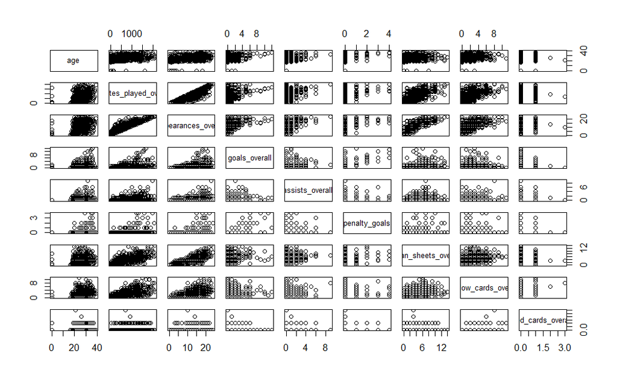

Para poder observar si hay colinealidad en el modelo de regersión, separamos los datos en dos grupos train y test para poder hacer cross validation.

```r
coef(modelo1)
```

```
                  (Intercept)                           age
                -1.231468e-15                 -2.003260e-18
              positionForward            positionGoalkeeper
                 2.325254e-15                  3.518213e-16
           positionMidfielder        minutes_played_overall
                 5.306208e-16                 -3.053697e-18
          minutes_played_home           appearances_overall
                 4.387359e-18                  4.272401e-17
             appearances_home                    goals_home
                 7.137949e-17                  1.000000e+00
                   goals_away               assists_overall
                 1.000000e+00                 -7.140959e-17
                 assists_home                 penalty_goals
                 6.522541e-17                 -2.695651e-17
               penalty_misses          clean_sheets_overall
                -5.507705e-16                 -3.375578e-17
            clean_sheets_home              conceded_overall
                -4.451004e-17                 -8.865508e-18
                conceded_home          yellow_cards_overall
                 6.397587e-18                  3.026505e-17
            red_cards_overall goals_involved_per_90_overall
                -7.748435e-17                  9.834907e-15
       assists_per_90_overall          goals_per_90_overall
                -9.949309e-15                 -9.771610e-15
            goals_per_90_home             goals_per_90_away
                -3.271226e-16                 -2.412736e-16
         min_per_goal_overall       conceded_per_90_overall
                 2.696510e-20                 -7.144268e-17
     min_per_conceded_overall                 min_per_match
                 5.111816e-19                  3.921179e-18
         min_per_card_overall          cards_per_90_overall
                 9.573784e-20                 -3.097630e-18
```

```r
predicciones
```

```
            1             4            18            20            21            25
-5.130902e-16  1.029274e-15  9.427144e-16 -8.073307e-16 -5.214182e-16 -1.077056e-15
           35            40            43            54            60            66
-1.410664e-15 -1.658038e-15  6.000000e+00 -7.445823e-16 -9.497767e-16  3.000000e+00
           70            72            79            82            85            88
-1.061911e-15  1.000000e+00 -1.378439e-15 -6.451339e-16  1.330631e-15  4.000000e+00
           95           105           110           114           121           123
 1.000000e+00 -7.303358e-16  5.000000e+00  1.000000e+00 -1.069882e-15 -6.779940e-16
          133           137           139           144           152           154
 1.000000e+00 -1.362275e-15  5.000000e+00  2.000000e+00 -1.222201e-15 -5.490147e-16
          161           163           169           172           174           178
 8.646848e-16  1.000000e+00  1.000000e+00 -6.215840e-16  1.000000e+00 -7.614378e-16
          184           193           198           208           210           224
 1.071221e-15 -7.389095e-16  1.000000e+00 -1.826126e-16 -2.094233e-16  1.512093e-15
          226           227           229           233           241           244
 1.000000e+00  5.000000e+00 -1.287009e-15  1.000000e+00 -7.164416e-16  1.000000e+00
          248           249           251           257           260           262
 3.000000e+00  5.000000e+00 -2.314583e-16  2.000000e+00  3.000000e+00 -2.239430e-16
          265           274           278           291           298           301
-1.491037e-15  1.000000e+00 -9.277252e-16 -4.272209e-16  1.000000e+00 -7.140287e-16
          307           312           319           321           348           350
-1.559775e-15  1.459637e-15  1.000000e+00  1.333666e-15 -1.287520e-15 -9.983041e-16
          368           373           377           378           381           382
-9.197122e-16 -7.520234e-16 -7.633375e-16 -7.858162e-17 -8.223641e-17 -9.296820e-16
          386           393           397           398           401           416
-8.154463e-16 -9.277252e-16 -7.746566e-16 -2.159177e-16 -8.427368e-16  5.746378e-17
          423           425           427           436           441           446
-7.388654e-16 -6.538711e-16  1.086111e-15 -1.272151e-15 -7.389095e-16 -1.198845e-15
          452           460           466           467           470           475
 2.000000e+00 -9.442482e-16  2.000000e+00 -1.172952e-15  1.000000e+00  9.000000e+00
          481           496           501           511           517           518
-1.226536e-15  1.000000e+00 -1.076518e-15 -4.235653e-16  5.000000e+00  9.000000e+00
          520           523           524           525           527           532
-9.177089e-16 -9.127144e-16 -4.872132e-16 -8.530069e-16 -3.221469e-17  1.000000e+00
          554           557           558           563           564           565
-5.179674e-16 -4.679645e-16 -1.057598e-15  1.000000e+00  2.000000e+00 -1.484062e-15
          567           580           583           586           587           593
 2.000000e+00 -7.696698e-16  1.000000e+00  1.055724e-15 -8.577408e-16 -1.595672e-15
          597           603           605           607           608           610
 8.846576e-16 -9.217154e-16 -5.549675e-16 -9.257220e-16  1.000000e+00 -6.451028e-16
          612           613           614           624           626           627
-9.281793e-16  1.000000e+01 -3.186675e-16 -2.327641e-16 -1.870879e-15 -1.984886e-16
          628
-7.033007e-16
```

| RMSE | R2 |
| --- | --- |
| 1.532546e-15 | 1 |

```r
car::vif(modelo1)
```

```
                                      GVIF Df GVIF^(1/(2*Df))
age                               1.412649  1        1.188549
position                          1.890085  3        1.111937
minutes_played_overall          104.594294  1       10.227135
minutes_played_home              79.920674  1        8.939836
appearances_overall              55.321755  1        7.437860
appearances_home                 44.305180  1        6.656214
goals_home                        4.298574  1        2.073300
goals_away                        4.916690  1        2.217361
assists_overall                   5.832214  1        2.414998
assists_home                      4.107612  1        2.026724
penalty_goals                     1.940672  1        1.393080
penalty_misses                    1.254664  1        1.120118
clean_sheets_overall             14.472271  1        3.804244
clean_sheets_home                11.402441  1        3.376750
conceded_overall                 22.250098  1        4.717001
conceded_home                     9.235274  1        3.038959
yellow_cards_overall              2.407194  1        1.551514
red_cards_overall                 1.209849  1        1.099931
goals_involved_per_90_overall 27509.729377  1      165.860572
assists_per_90_overall         4647.870338  1       68.175291
goals_per_90_overall          21039.257380  1      145.049155
goals_per_90_home                 3.289824  1        1.813787
goals_per_90_away                 3.123766  1        1.767418
min_per_goal_overall              1.542187  1        1.241848
conceded_per_90_overall           1.301549  1        1.140855
min_per_conceded_overall          2.538564  1        1.593287
min_per_match                     3.866813  1        1.966421
min_per_card_overall              1.855157  1        1.362042
cards_per_90_overall              1.041795  1        1.020684
```

```r
coef(modelo2)
```

```
             (Intercept)                      age          positionForward
            2.161250e-16            -4.920021e-17             1.085899e-15
      positionGoalkeeper       positionMidfielder               goals_home
            7.128534e-16             1.483411e-16             1.000000e+00
              goals_away          assists_overall             assists_home
            1.000000e+00            -2.609557e-17             8.129443e-17
           penalty_goals           penalty_misses     yellow_cards_overall
           -3.802341e-17            -5.388124e-16             1.254087e-17
       red_cards_overall        goals_per_90_home        goals_per_90_away
           -3.906659e-17             1.201466e-16             1.548985e-16
    min_per_goal_overall  conceded_per_90_overall min_per_conceded_overall
            3.563444e-21            -8.350663e-17             1.716539e-19
           min_per_match     min_per_card_overall     cards_per_90_overall
           -2.388577e-18             3.473585e-19            -2.101978e-18
```

```r
predicciones2
```

```
            1             4            18            20            21            25
-8.402559e-16 -2.758308e-16  2.497990e-18 -9.866917e-16 -1.300029e-15 -3.510998e-16
           35            40            43            54            60            66
-1.802688e-15 -1.157466e-15  6.000000e+00  1.837043e-16 -1.133586e-15  3.000000e+00
           70            72            79            82            85            88
-1.025896e-15  1.000000e+00 -1.434336e-15 -7.603813e-17  1.036372e-15  4.000000e+00
           95           105           110           114           121           123
 1.000000e+00 -1.223829e-15  5.000000e+00  1.000000e+00 -7.582237e-16 -6.601439e-16
          133           137           139           144           152           154
 1.000000e+00 -1.677776e-15  5.000000e+00  2.000000e+00 -8.576852e-16 -7.623337e-16
          161           163           169           172           174           178
-2.009399e-16  1.000000e+00  1.000000e+00 -8.300576e-16  1.000000e+00 -8.977933e-16
          184           193           198           208           210           224
-8.848504e-17 -5.703379e-16  1.000000e+00 -9.941646e-16 -1.027467e-15 -2.577549e-16
          226           227           229           233           241           244
 1.000000e+00  5.000000e+00 -1.395957e-15  1.000000e+00 -7.633519e-16  1.000000e+00
          248           249           251           257           260           262
 3.000000e+00  5.000000e+00 -1.107952e-15  2.000000e+00  3.000000e+00 -3.225583e-16
          265           274           278           291           298           301
-1.163782e-15  1.000000e+00 -2.518266e-16 -5.951836e-16  1.000000e+00 -8.296770e-16
          307           312           319           321           348           350
-1.177966e-15 -5.870656e-17  1.000000e+00 -2.482601e-17 -1.370920e-15 -1.589130e-15
          368           373           377           378           381           382
-5.502581e-17 -7.575375e-16 -8.045950e-16 -7.537715e-16 -7.648290e-16 -6.574143e-16
          386           393           397           398           401           416
-8.942636e-16 -2.518266e-16 -8.767170e-16 -9.384185e-16 -9.537100e-16 -6.503362e-16
          423           425           427           436           441           446
-1.384787e-15 -8.345100e-16  2.535278e-16 -1.011519e-15 -5.703379e-16 -1.409103e-15
          452           460           466           467           470           475
 2.000000e+00 -9.222047e-16  2.000000e+00 -1.003582e-15  1.000000e+00  9.000000e+00
          481           496           501           511           517           518
-9.190678e-16  1.000000e+00 -8.126734e-16 -9.097739e-16  5.000000e+00  9.000000e+00
          520           523           524           525           527           532
-5.825597e-18 -1.246719e-15 -6.699268e-16 -7.107717e-16 -1.175544e-15  1.000000e+00
          554           557           558           563           564           565
-9.696766e-16 -7.711140e-16 -1.304967e-15  1.000000e+00  2.000000e+00 -1.356350e-15
          567           580           583           586           587           593
 2.000000e+00 -8.260314e-16  1.000000e+00  3.672196e-16 -4.407479e-16 -9.527938e-16
          597           603           605           607           608           610
 1.466674e-16 -1.042260e-16 -1.086890e-15 -2.026264e-16  1.000000e+00 -5.217309e-16
          612           613           614           624           626           627
-5.669623e-16  1.000000e+01 -7.746543e-16 -1.149399e-15 -1.640009e-15 -8.188559e-16
          628
-6.393940e-16
```

| RMSE | R2 |
| --- | --- |
| 1.209028e-15 | 1 |

```r
car::vif(modelo2)
```

```
                             GVIF Df GVIF^(1/(2*Df))
age                      1.351788  1        1.162664
position                 1.609207  3        1.082518
goals_home               3.952501  1        1.988090
goals_away               4.435933  1        2.106165
assists_overall          4.090323  1        2.022455
assists_home             3.887614  1        1.971703
penalty_goals            1.804644  1        1.343370
penalty_misses           1.180862  1        1.086675
yellow_cards_overall     1.643565  1        1.282016
red_cards_overall        1.179901  1        1.086232
goals_per_90_home        2.771625  1        1.664820
goals_per_90_away        2.977884  1        1.725655
min_per_goal_overall     1.386235  1        1.177385
conceded_per_90_overall  1.106849  1        1.052069
min_per_conceded_overall 1.403700  1        1.184778
min_per_match            2.172974  1        1.474101
min_per_card_overall     1.473145  1        1.213732
cards_per_90_overall     1.037518  1        1.018586
```

Ahora se implementará el modelo de regresión RIDGE

```r
pacman::p_load(pacman,dplyr, ggplot2, rio, gridExtra, scales, ggcorrplot, e1071)
```

```r
summary(train.datos)
```

```
      age          position         minutes_played_overall minutes_played_home
 Min.   : 0.00   Length:510         Min.   :   0.0         Min.   :   0.00
 1st Qu.:21.00   Class :character   1st Qu.: 145.0         1st Qu.:  70.75
 Median :25.00   Mode  :character   Median : 562.0         Median : 277.50
 Mean   :25.06                      Mean   : 648.8         Mean   : 325.68
 3rd Qu.:29.00                      3rd Qu.:1073.0         3rd Qu.: 540.00
 Max.   :39.00                      Max.   :2070.0         Max.   :1080.00
 appearances_overall appearances_home goals_overall       goals_home
 Min.   : 0.00       Min.   : 0.000   Min.   : 0.0000   Min.   :0.0000
 1st Qu.: 4.00       1st Qu.: 2.000   1st Qu.: 0.0000   1st Qu.:0.0000
 Median :10.50       Median : 5.000   Median : 0.0000   Median :0.0000
 Mean   :10.06       Mean   : 5.037   Mean   : 0.6686   Mean   :0.3922
 3rd Qu.:16.00       3rd Qu.: 8.000   3rd Qu.: 1.0000   3rd Qu.:0.0000
 Max.   :24.00       Max.   :12.000   Max.   :12.0000   Max.   :7.0000
   goals_away     assists_overall   assists_home    penalty_goals    penalty_misses
 Min.   :0.0000   Min.   :0.0000   Min.   :0.0000   Min.   :0.0000   Min.   :0.00000
 1st Qu.:0.0000   1st Qu.:0.0000   1st Qu.:0.0000   1st Qu.:0.0000   1st Qu.:0.00000
 Median :0.0000   Median :0.0000   Median :0.0000   Median :0.0000   Median :0.00000
 Mean   :0.2765   Mean   :0.4392   Mean   :0.2569   Mean   :0.0902   Mean   :0.01765
 3rd Qu.:0.0000   3rd Qu.:1.0000   3rd Qu.:0.0000   3rd Qu.:0.0000   3rd Qu.:0.00000
 Max.   :6.0000   Max.   :9.0000   Max.   :4.0000   Max.   :4.0000   Max.   :1.00000
 clean_sheets_overall clean_sheets_home conceded_overall conceded_home
 Min.   : 0.0         Min.   :0.000     Min.   : 0.000   Min.   : 0.000
 1st Qu.: 1.0         1st Qu.:0.000     1st Qu.: 2.000   1st Qu.: 0.000
 Median : 2.5         Median :2.000     Median : 6.000   Median : 2.000
 Mean   : 3.2         Mean   :2.027     Mean   : 7.094   Mean   : 2.765
 3rd Qu.: 5.0         3rd Qu.:3.000     3rd Qu.:11.000   3rd Qu.: 5.000
 Max.   :13.0         Max.   :9.000     Max.   :27.000   Max.   :10.000
 yellow_cards_overall red_cards_overall goals_involved_per_90_overall
 Min.   : 0.000       Min.   :0.0000    Min.   :0.0000
 1st Qu.: 0.000       1st Qu.:0.0000    1st Qu.:0.0000
 Median : 1.000       Median :0.0000    Median :0.0000
 Mean   : 1.888       Mean   :0.1059    Mean   :0.1349
 3rd Qu.: 3.000       3rd Qu.:0.0000    3rd Qu.:0.2000
 Max.   :11.000       Max.   :3.0000    Max.   :5.0000
 assists_per_90_overall goals_per_90_overall goals_per_90_home goals_per_90_away
 Min.   :0.00000        Min.   :0.00000      Min.   :0.00000   Min.   :0.00000
 1st Qu.:0.00000        1st Qu.:0.00000      1st Qu.:0.00000   1st Qu.:0.00000
 Median :0.00000        Median :0.00000      Median :0.00000   Median :0.00000
 Mean   :0.05163        Mean   :0.08324      Mean   :0.08263   Mean   :0.06273
 3rd Qu.:0.06000        3rd Qu.:0.08000      3rd Qu.:0.00000   3rd Qu.:0.00000
 Max.   :1.44000        Max.   :5.00000      Max.   :1.57000   Max.   :1.53000
 min_per_goal_overall conceded_per_90_overall min_per_conceded_overall min_per_match
 Min.   :   0.0       Min.   : 0.0000         Min.   :  0.00           Min.   : 0.00
 1st Qu.:   0.0       1st Qu.: 0.5725         1st Qu.: 53.00           1st Qu.:34.00
 Median :   0.0       Median : 0.9250         Median : 79.00           Median :59.00
 Mean   : 175.9       Mean   : 0.9888         Mean   : 83.67           Mean   :54.01
 3rd Qu.: 209.5       3rd Qu.: 1.2700         3rd Qu.:112.00           3rd Qu.:77.00
 Max.   :2047.0       Max.   :12.8600         Max.   :593.00           Max.   :90.00
 min_per_card_overall cards_per_90_overall
 Min.   :   0.0       Min.   : 0.0000
 1st Qu.:   0.0       1st Qu.: 0.0000
 Median : 173.5       Median : 0.2000
 Mean   : 225.7       Mean   : 0.4136
 3rd Qu.: 325.5       3rd Qu.: 0.4000
 Max.   :1800.0       Max.   :45.0000
```

```r
summary(test.datos)
```

```
      age          position         minutes_played_overall minutes_played_home
 Min.   : 0.00   Length:127         Min.   :   0.0         Min.   :   0.0
 1st Qu.:22.00   Class :character   1st Qu.: 167.5         1st Qu.:  54.0
 Median :25.00   Mode  :character   Median : 663.0         Median : 348.0
 Mean   :25.31                      Mean   : 735.0         Mean   : 366.2
 3rd Qu.:29.00                      3rd Qu.:1192.0         3rd Qu.: 624.0
 Max.   :37.00                      Max.   :2070.0         Max.   :1080.0
 appearances_overall appearances_home goals_overall       goals_home       goals_away
 Min.   : 0.00       Min.   : 0.000   Min.   : 0.0000   Min.   :0.0000   Min.   :0.000
 1st Qu.: 4.50       1st Qu.: 2.000   1st Qu.: 0.0000   1st Qu.:0.0000   1st Qu.:0.000
 Median :13.00       Median : 7.000   Median : 0.0000   Median :0.0000   Median :0.000
 Mean   :11.12       Mean   : 5.488   Mean   : 0.8189   Mean   :0.5039   Mean   :0.315
 3rd Qu.:17.00       3rd Qu.: 8.000   3rd Qu.: 1.0000   3rd Qu.:0.5000   3rd Qu.:0.000
 Max.   :23.00       Max.   :12.000   Max.   :10.0000   Max.   :7.0000   Max.   :5.000
 assists_overall   assists_home    penalty_goals    penalty_misses
 Min.   :0.0000   Min.   :0.0000   Min.   :0.0000   Min.   :0.00000
 1st Qu.:0.0000   1st Qu.:0.0000   1st Qu.:0.0000   1st Qu.:0.00000
 Median :0.0000   Median :0.0000   Median :0.0000   Median :0.00000
 Mean   :0.4488   Mean   :0.3622   Mean   :0.1496   Mean   :0.05512
 3rd Qu.:0.5000   3rd Qu.:0.0000   3rd Qu.:0.0000   3rd Qu.:0.00000
 Max.   :5.0000   Max.   :4.0000   Max.   :4.0000   Max.   :2.00000
 clean_sheets_overall clean_sheets_home conceded_overall conceded_home
 Min.   : 0.000       Min.   :0.000     Min.   : 0.000   Min.   : 0.000
 1st Qu.: 1.000       1st Qu.:1.000     1st Qu.: 2.000   1st Qu.: 0.000
 Median : 3.000       Median :2.000     Median : 6.000   Median : 2.000
 Mean   : 3.449       Mean   :2.157     Mean   : 7.913   Mean   : 3.181
 3rd Qu.: 5.000       3rd Qu.:3.000     3rd Qu.:14.000   3rd Qu.: 6.000
 Max.   :14.000       Max.   :9.000     Max.   :24.000   Max.   :11.000
 yellow_cards_overall red_cards_overall goals_involved_per_90_overall
 Min.   : 0.000       Min.   :0.0000    Min.   :0.0000
 1st Qu.: 0.000       1st Qu.:0.0000    1st Qu.:0.0000
 Median : 1.000       Median :0.0000    Median :0.0000
 Mean   : 2.102       Mean   :0.1181    Mean   :0.1109
 3rd Qu.: 3.000       3rd Qu.:0.0000    3rd Qu.:0.1500
 Max.   :10.000       Max.   :1.0000    Max.   :0.7600
 assists_per_90_overall goals_per_90_overall goals_per_90_home goals_per_90_away
 Min.   :0.00000        Min.   :0.00000      Min.   :0.00000   Min.   :0.00000
 1st Qu.:0.00000        1st Qu.:0.00000      1st Qu.:0.00000   1st Qu.:0.00000
 Median :0.00000        Median :0.00000      Median :0.00000   Median :0.00000
 Mean   :0.04079        Mean   :0.07024      Mean   :0.08346   Mean   :0.05559
 3rd Qu.:0.03500        3rd Qu.:0.07500      3rd Qu.:0.04500   3rd Qu.:0.00000
 Max.   :0.55000        Max.   :0.67000      Max.   :0.97000   Max.   :0.84000
 min_per_goal_overall conceded_per_90_overall min_per_conceded_overall min_per_match
 Min.   :   0.0       Min.   :0.0000          Min.   :  0.00           Min.   : 0.00
 1st Qu.:   0.0       1st Qu.:0.5450          1st Qu.: 59.50           1st Qu.:33.50
 Median :   0.0       Median :0.9500          Median : 84.00           Median :58.00
 Mean   : 222.6       Mean   :0.9929          Mean   : 87.55           Mean   :55.56
 3rd Qu.: 231.0       3rd Qu.:1.2150          3rd Qu.:112.50           3rd Qu.:82.00
 Max.   :1947.0       Max.   :9.0000          Max.   :285.00           Max.   :90.00
 min_per_card_overall cards_per_90_overall
 Min.   :   0.0       Min.   :0.0000
 1st Qu.:   0.0       1st Qu.:0.0000
 Median : 189.0       Median :0.1700
 Mean   : 275.6       Mean   :0.2905
 3rd Qu.: 410.5       3rd Qu.:0.3750
 Max.   :1710.0       Max.   :4.8600
```

```r
#Para conocer las dimensiones de mis datos
dim(train.datos)
```

```
[1] 510  30
```

```r
dim(test.datos)
```

```
[1] 127  30
```

```r
head(x)
```

```
  (Intercept) age positionForward positionGoalkeeper positionMidfielder
2           1  29               0                  0                  0
3           1  24               0                  0                  1
5           1  20               0                  0                  1
6           1  30               1                  0                  0
7           1  20               0                  0                  0
8           1  27               0                  1                  0
  minutes_played_overall minutes_played_home appearances_overall appearances_home
2                   1887                 897                  22               11
3                    536                 294                  11                5
5                     30                   0                   1                0
6                    520                 280                   8                5
7                     66                   2                   3                1
8                    406                  90                   5                1
  goals_home goals_away assists_overall assists_home penalty_goals penalty_misses
```

[output cut: 41 more lines]

```r
head(x)
```

```
  age positionForward positionGoalkeeper positionMidfielder minutes_played_overall
2  29               0                  0                  0                   1887
3  24               0                  0                  1                    536
5  20               0                  0                  1                     30
6  30               1                  0                  0                    520
7  20               0                  0                  0                     66
8  27               0                  1                  0                    406
  minutes_played_home appearances_overall appearances_home goals_home goals_away
2                 897                  22               11          2          1
3                 294                  11                5          2          0
5                   0                   1                0          0          0
6                 280                   8                5          0          0
7                   2                   3                1          0          0
8                  90                   5                1          0          0
  assists_overall assists_home penalty_goals penalty_misses clean_sheets_overall
```

[output cut: 41 more lines]

```r
y
```

```
  [1]  3  2  0  0  0  0  0  0  1  0  2  0  0  0  1  0  3  0  0  1  0  4  0  0  0  2  0  6
 [29]  4  0  0  0  0  1  0  0  0  0  1  0  0  0  0  2  3  0  0  0  0  5  0  1  0  0  3  0
 [57]  1  0  0  1  0  0  0  0  0  1  0  0  0  0  0  0  0  6  0  0  1  3  0  0  0  0  0  4
 [85]  0  1  0  0  0  0  0  1  0  0  3  2  0  2  0  1  4  1  0  2  0  0  0  0  0  1  6  0
[113]  0  1  1  0  0 12  0  1  0  1  0  0  0  0  0  0  6  5  0  1  6  0  0  0  8  0  0  2
[141]  3  0  0  0  0  0  2  2  0  0  1  0  0  1  0  0  0  0  0  1  0  0  0  0  2  1  0  0
[169]  0  1  0  1  0  0  1  1  0  1  0  0  1  0  3  0  0  0  2  0  0  0  0  0  0  0  0  3
[197]  0  1  0  0  2  0  0  1  1  0  0  0  0  0  1  0  1  0  0  0  3  0  0  0  0  0  0  0
[225]  0  0  0  0  3  0  0  3  0  0  1  0  0  7  0  0  0  0  0  0  3  0  1  2  0  0  6  0
[253]  0  1  0  0  0  1  0  2  0  0  1  3  0  0  0  0  0  0  0  0  0  0  1  0  0  0  0  0
[281]  0  0  0  0  0  0  0  0  0  0  0  0  0  0  0  0  0  0  1  0  0  0  0  3  0  2  0  0
[309]  0  2  2  0  0  0  2  0  0  0  0  0  0  0  0  0  3  0  1  0  0  1  0  1  2  1  0  0
[337]  0  0  0  0  4  0  0  3  0  0  0  0  1  1  0  0  0  1  1  0  0  0  0  1  0  0  1  0
[365]  0  0  2  0  1  0  3  1  0  0  0  0  0  0  0  0  1  0  0  2  1  0  0  0  0 10  0  0
[393]  0 11  6  0  0  0  0  0  1  4  0  1  0  0  0  0  0  3  1  2  0  0  0  0  0  1  2  0
[421]  5  0  0  0  0  2  0  0  0  0  0  0  0  0  0  0  0  0  0  5  3  3  0  0  1  0  0  0
[449]  0  1  0  0  0  1  0  0  0  0  0  0  0  0  1  0  0  0  0  0  2  0  1  2  0  0  2  0
[477]  1  0  0  1  1  2  0  0  1  0  1  3  0  2  0  1  0  0  1  1  3  0  0  0  0  0  0  3
[505]  0  0  2  0  0  0
```

```r
dim(coef(ridge.model))
```

```
[1]  32 100
```

```r
#construye 100 modelos por defecto
coef(ridge.model)
```

```
32 x 100 sparse Matrix of class "dgCMatrix"
```

```
  [[ suppressing 38 column names ‘s0’, ‘s1’, ‘s2’ ... ]]
  [[ suppressing 38 column names ‘s0’, ‘s1’, ‘s2’ ... ]]
```

```
(Intercept)             6.686275e-01  6.544810e-01  6.531204e-01  6.516308e-01
age                     6.026698e-38  7.133766e-05  7.819674e-05  8.570563e-05
positionForward         9.930400e-37  1.184091e-03  1.298867e-03  1.424698e-03
positionGoalkeeper     -6.965942e-37 -8.271800e-04 -9.069945e-04 -9.944248e-04
positionMidfielder     -9.368087e-38 -1.114346e-04 -1.222075e-04 -1.340121e-04
minutes_played_overall  1.065303e-39  1.258757e-06  1.379547e-06  1.511734e-06
minutes_played_home     2.131510e-39  2.519770e-06  2.761699e-06  3.026475e-06
appearances_overall     9.833340e-38  1.162815e-04  1.274500e-04  1.396738e-04
appearances_home        1.901041e-37  2.248445e-04  2.464448e-04  2.700870e-04
goals_home              1.411286e-36  1.681783e-03  1.844696e-03  2.023281e-03
goals_away              1.699695e-36  2.024979e-03  2.221086e-03  2.436045e-03
assists_overall         5.347989e-37  6.336941e-04  6.946962e-04  7.614892e-04
assists_home            6.711808e-37  7.948952e-04  8.713729e-04  9.551015e-04

(Intercept)             6.500004e-01  6.482166e-01  6.462652e-01  6.441314e-01
age                     9.392343e-05  1.029146e-04  1.127490e-04  1.235022e-04
positionForward         1.562634e-03  1.713821e-03  1.879512e-03  2.061073e-03
positionGoalkeeper     -1.090177e-03 -1.195023e-03 -1.309799e-03 -1.435416e-03
positionMidfielder     -1.469452e-04 -1.611123e-04 -1.766284e-04 -1.936183e-04
minutes_played_overall  1.656342e-06  1.814489e-06  1.987385e-06  2.176335e-06
minutes_played_home     3.316164e-06  3.633013e-06  3.979457e-06  4.358123e-06
appearances_overall     1.530487e-04  1.676787e-04  1.836765e-04  2.011639e-04
appearances_home        2.959565e-04  3.242551e-04  3.552010e-04  3.890301e-04
goals_home              2.219020e-03  2.433536e-03  2.668596e-03  2.926130e-03
goals_away              2.671641e-03  2.929820e-03  3.212707e-03  3.522617e-03
assists_overall         8.346051e-04  9.146224e-04  1.002169e-03  1.097924e-03
assists_home            1.046746e-03  1.147028e-03  1.256731e-03  1.376702e-03

(Intercept)             6.417988e-01  6.392499e-01  6.364658e-01  6.334262e-01
age                     1.352558e-04  1.480979e-04  1.621234e-04  1.774340e-04
positionForward         2.259994e-03  2.477898e-03  2.716554e-03  2.977885e-03
positionGoalkeeper     -1.572861e-03 -1.723204e-03 -1.887602e-03 -2.067306e-03
positionMidfielder     -2.122181e-04 -2.325751e-04 -2.548497e-04 -2.792151e-04
minutes_played_overall  2.382743e-06  2.608124e-06  2.854099e-06  3.122408e-06
minutes_played_home     4.771845e-06  5.223672e-06  5.716882e-06  6.254987e-06
appearances_overall     2.202721e-04  2.411425e-04  2.639272e-04  2.887892e-04
appearances_home        4.259971e-04  4.663762e-04  5.104623e-04  5.585718e-04
goals_home              3.208240e-03  3.517216e-03  3.855551e-03  4.225956e-03
goals_away              3.862075e-03  4.233827e-03  4.640864e-03  5.086434e-03
assists_overall         1.202624e-03  1.317063e-03  1.442097e-03  1.578650e-03
```

[output cut: 88 more lines]

```
positionForward         2.712441e-02  2.941623e-02 ......
positionGoalkeeper     -1.735108e-02 -1.867406e-02 ......
positionMidfielder     -2.406128e-03 -2.593867e-03 ......
minutes_played_overall  2.377247e-05  2.535757e-05 ......
minutes_played_home     4.813610e-05  5.140366e-05 ......
appearances_overall     2.232905e-03  2.385109e-03 ......
appearances_home        4.336845e-03  4.634460e-03 ......
goals_home              3.838212e-02  4.164819e-02 ......
goals_away              4.592210e-02  4.979676e-02 ......
assists_overall         1.271470e-02  1.363369e-02 ......
assists_home            1.575998e-02  1.687967e-02 ......

 ..............................
 ........suppressing 62 columns and 6 rows in show(); maybe adjust 'options(max.print= *, width = *)'
 ..............................
```

```
  [[ suppressing 38 column names ‘s0’, ‘s1’, ‘s2’ ... ]]
```

```
yellow_cards_overall           1.435804e-37  1.689647e-04  1.851063e-04  2.027547e-04
red_cards_overall              3.749873e-37  4.421821e-04  4.845209e-04  5.308319e-04
goals_involved_per_90_overall  2.297679e-36  2.732074e-03  2.996089e-03  3.285369e-03
assists_per_90_overall         2.160314e-36  2.557070e-03  2.802934e-03  3.072073e-03
goals_per_90_overall           2.520685e-36  2.999794e-03  3.289953e-03  3.607933e-03
goals_per_90_home              4.589537e-36  5.468104e-03  5.997682e-03  6.578172e-03
goals_per_90_away              4.859343e-36  5.787798e-03  6.348149e-03  6.962333e-03
min_per_goal_overall           1.245453e-39  1.475992e-06  1.618106e-06  1.773714e-06
conceded_per_90_overall       -3.552091e-38 -4.258315e-05 -4.673518e-05 -5.129205e-05
min_per_conceded_overall       4.373518e-39  5.156300e-06  5.649912e-06  6.189811e-06
min_per_match                  1.008887e-38  1.186593e-05  1.299881e-05  1.423730e-05
min_per_card_overall           1.557953e-39  1.843991e-06  2.021288e-06  2.215369e-06
cards_per_90_overall          -2.340638e-38 -2.765692e-05 -3.031109e-05 -3.321551e-05

yellow_cards_overall           2.220437e-04  2.431171e-04  2.661298e-04  2.912481e-04
red_cards_overall              5.814713e-04  6.368239e-04  6.973047e-04  7.633605e-04
goals_involved_per_90_overall  3.602281e-03  3.949402e-03  4.329540e-03  4.745748e-03
assists_per_90_overall         3.366617e-03  3.688876e-03  4.041350e-03  4.426747e-03
goals_per_90_overall           3.956352e-03  4.338063e-03  4.756177e-03  5.214080e-03
goals_per_90_home              7.214395e-03  7.911611e-03  8.675556e-03  9.512488e-03
goals_per_90_away              7.635438e-03  8.373015e-03  9.181118e-03  1.006635e-02
min_per_goal_overall           1.944059e-06  2.130491e-06  2.334476e-06  2.557600e-06
conceded_per_90_overall       -5.629324e-05 -6.178205e-05 -6.780602e-05 -7.441732e-05
min_per_conceded_overall       6.780144e-06  7.425389e-06  8.130371e-06  8.900288e-06
min_per_match                  1.559075e-05  1.706920e-05  1.868346e-05  2.044513e-05
min_per_card_overall           2.427770e-06  2.660158e-06  2.914337e-06  3.192260e-06
cards_per_90_overall          -3.639286e-05 -3.986772e-05 -4.366666e-05 -4.781835e-05

yellow_cards_overall           3.186501e-04  3.485259e-04  3.810779e-04  4.165210e-04
red_cards_overall              8.354712e-04  9.141514e-04  9.999510e-04  1.093457e-03
goals_involved_per_90_overall  5.201345e-03  5.699934e-03  6.245422e-03  6.842042e-03
assists_per_90_overall         4.847988e-03  5.308225e-03  5.810850e-03  6.359506e-03
goals_per_90_overall           5.715455e-03  6.264306e-03  6.864982e-03  7.522200e-03
goals_per_90_home              1.042922e-02  1.143318e-02  1.253244e-02  1.373578e-02
goals_per_90_away              1.103588e-02  1.209755e-02  1.325986e-02  1.453205e-02
min_per_goal_overall           2.801582e-06  3.068276e-06  3.359687e-06  3.677972e-06
conceded_per_90_overall       -8.167319e-05 -8.963644e-05 -9.837600e-05 -1.079675e-04
min_per_conceded_overall       9.740718e-06  1.065764e-05  1.165744e-05  1.274692e-05
min_per_match                  2.236661e-05  2.446114e-05  2.674280e-05  2.922649e-05
min_per_card_overall           3.496036e-06  3.827942e-06  4.190426e-06  4.586123e-06
```

[output cut: 84 more lines]

```
cards_per_90_overall          -3.955861e-04 -4.250342e-04 -4.558902e-04 -4.880928e-04

yellow_cards_overall           2.873463e-03  3.031584e-03 ......
red_cards_overall              7.923388e-03  8.405526e-03 ......
goals_involved_per_90_overall  5.901542e-02  6.368155e-02 ......
assists_per_90_overall         4.966834e-02  5.305457e-02 ......
goals_per_90_overall           6.601525e-02  7.135292e-02 ......
goals_per_90_home              1.239105e-01  1.343346e-01 ......
goals_per_90_away              1.301519e-01  1.409912e-01 ......
min_per_goal_overall           2.983488e-05  3.202522e-05 ......
conceded_per_90_overall       -1.096146e-03 -1.201082e-03 ......
min_per_conceded_overall       9.143514e-05  9.683228e-05 ......
min_per_match                  1.993794e-04  2.101364e-04 ......
min_per_card_overall           3.623437e-05  3.879580e-05 ......
cards_per_90_overall          -5.215569e-04 -5.561716e-04 ......
```

```r
ridge.model$lambda
```

```
  [1] 1337.7899928 1218.9444169 1110.6567545 1011.9890695  922.0867497  840.1711043
  [7]  765.5326190  697.5248110  635.5586292  579.0973523  527.6519396  480.7767955
 [13]  438.0659101  399.1493420  363.6900146  331.3807960  301.9418394  275.1181586
 [19]  250.6774197  228.4079286  208.1167977  189.6282750  172.7822217  157.4327253
 [25]  143.4468359  130.7034144  119.0920833  108.5122708   98.8723398   90.0887936
 [31]   82.0855535   74.7932991   68.1488686   62.0947109   56.5783879   51.5521199
 [37]   46.9723716   42.7994756   38.9972882   35.5328766   32.3762337   29.5000184
 [43]   26.8793180   24.4914335   22.3156821   20.3332184   18.5268713   16.8809951
 [49]   15.3813340   14.0148987   12.7698537   11.6354151   10.6017569    9.6599260
 [55]    8.8017648    8.0198403    7.3073798    6.6582123    6.0667151    5.5277648
 [61]    5.0366934    4.5892475    4.1815514    3.8100739    3.4715974    3.1631903
 [67]    2.8821812    2.6261361    2.3928374    2.1802644    1.9865757    1.8100938
 [73]    1.6492900    1.5027716    1.3692696    1.2476274    1.1367916    1.0358022
 [79]    0.9437844    0.8599412    0.7835464    0.7139383    0.6505140    0.5927241
 [85]    0.5400681    0.4920900    0.4483740    0.4085417    0.3722480    0.3391785
 [91]    0.3090468    0.2815920    0.2565761    0.2337826    0.2130140    0.1940904
 [97]    0.1768480    0.1611373    0.1468223    0.1337790
```

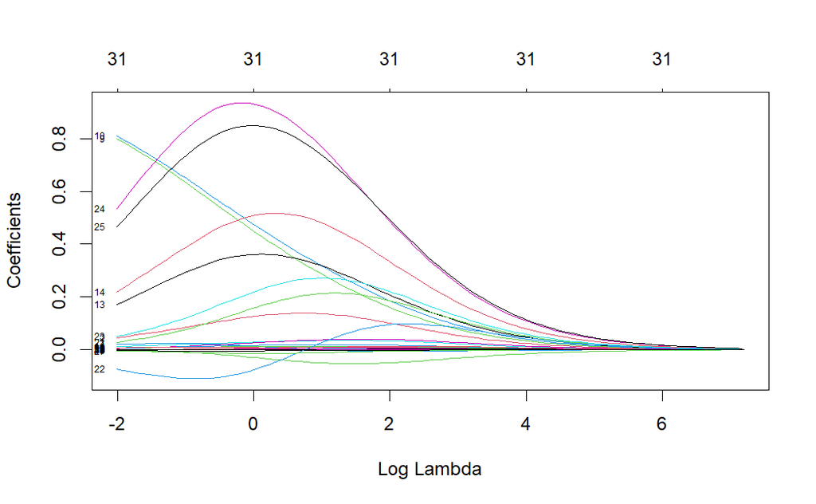

```r
#Para saber el lambda del modelo 20
ridge.model$lambda[20]
```

```
[1] 228.4079
```

```r
log(ridge.model$lambda[20])
```

```
[1] 5.431133
```

```r
coef(ridge.model)[,20]
```

```
                  (Intercept)                           age
                 5.969617e-01                  3.609566e-04
              positionForward            positionGoalkeeper
                 6.177244e-03                 -4.241218e-03
           positionMidfielder        minutes_played_overall
                -5.753233e-04                  6.321556e-06
          minutes_played_home           appearances_overall
                 1.268023e-05                  5.859005e-04
             appearances_home                    goals_home
                 1.133819e-03                  8.754907e-03
                   goals_away               assists_overall
                 1.053027e-02                  3.220275e-03
                 assists_home                 penalty_goals
                 4.030742e-03                  1.258085e-02
               penalty_misses          clean_sheets_overall
                 2.114366e-02                  1.254320e-03
            clean_sheets_home              conceded_overall
                 1.773715e-03                  4.451759e-04
                conceded_home          yellow_cards_overall
                 9.035272e-04                  8.336101e-04
            red_cards_overall goals_involved_per_90_overall
                 2.200995e-03                  1.408758e-02
       assists_per_90_overall          goals_per_90_overall
                 1.293140e-02                  1.552357e-02
            goals_per_90_home             goals_per_90_away
                 2.843817e-02                  3.006097e-02
         min_per_goal_overall       conceded_per_90_overall
                 7.506768e-06                 -2.272251e-04
     min_per_conceded_overall                 min_per_match
                 2.564066e-05                  5.840480e-05
         min_per_card_overall          cards_per_90_overall
                 9.328082e-06                 -1.388882e-04
```

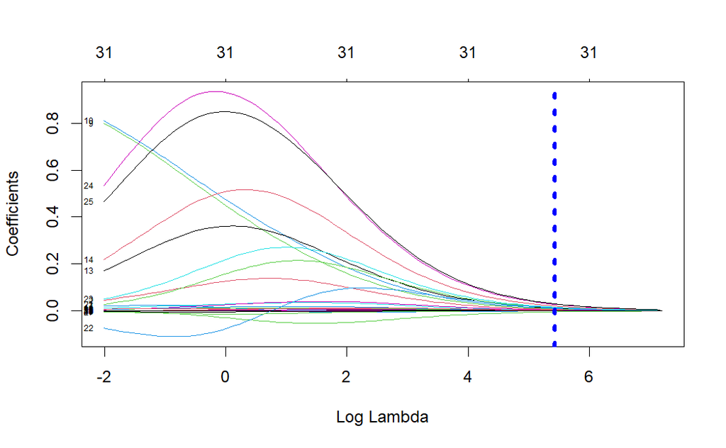

```r
plot(ridge.model,"lambda",label=TRUE)
abline(v=log(ridge.model$lambda[20]), col="blue",lwd= 4,lty =3)
```

```r
#Se hace otro ejemplo, pero esta vez con el modelo 45
ridge.model$lambda[45]
```

```
[1] 22.31568
```

```r
log(ridge.model$lambda[45])
```

```
[1] 3.10529
```

```r
coef(ridge.model)[,45]
```

```
                  (Intercept)                           age
                 2.087800e-01                  2.274909e-03
              positionForward            positionGoalkeeper
                 5.020105e-02                 -2.973196e-02
           positionMidfielder        minutes_played_overall
                -4.155426e-03                  3.733450e-05
          minutes_played_home           appearances_overall
                 7.656181e-05                  3.554006e-03
             appearances_home                    goals_home
                 6.935576e-03                  7.192869e-02
                   goals_away               assists_overall
                 8.541364e-02                  2.103301e-02
                 assists_home                 penalty_goals
                 2.574643e-02                  9.998261e-02
               penalty_misses          clean_sheets_overall
                 1.656524e-01                  7.862904e-03
            clean_sheets_home              conceded_overall
                 1.119256e-02                  2.533286e-03
                conceded_home          yellow_cards_overall
                 5.035797e-03                  3.969903e-03
            red_cards_overall goals_involved_per_90_overall
                 1.168591e-02                  1.038897e-01
       assists_per_90_overall          goals_per_90_overall
                 7.829044e-02                  1.182054e-01
            goals_per_90_home             goals_per_90_away
                 2.296153e-01                  2.390860e-01
         min_per_goal_overall       conceded_per_90_overall
                 5.005481e-05                 -2.253733e-03
     min_per_conceded_overall                 min_per_match
                 1.312489e-04                  2.728924e-04
         min_per_card_overall          cards_per_90_overall
                 5.922857e-05                 -8.155278e-04
```

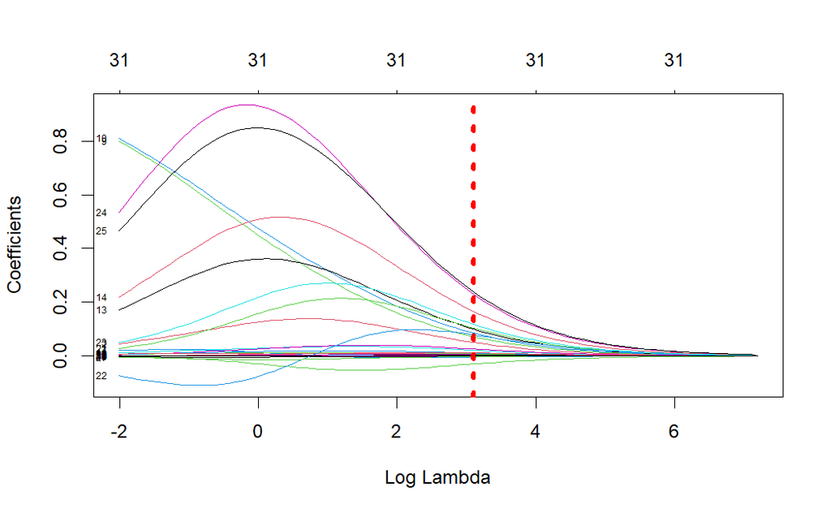

```r
plot(ridge.model,"lambda",label= TRUE)
abline(v=log(ridge.model$lambda[45]), col="red",lwd= 4,lty =3)
```

```r
x.test.datos=model.matrix(goals_overall~.,test.datos)[,-1]
pred=predict(ridge.model, s=ridge.model$lambda[45],newx = x.test.datos)
pred
```

```
           s1
1   0.2861590
4   0.3607096
18  0.3346236
20  0.4906633
21  0.6803038
25  0.9204951
35  0.5146744
40  0.5918781
43  2.1494876
54  0.2451474
60  0.3542864
66  1.3364552
70  0.3074487
72  1.0100686
```

[output cut: 113 more lines]

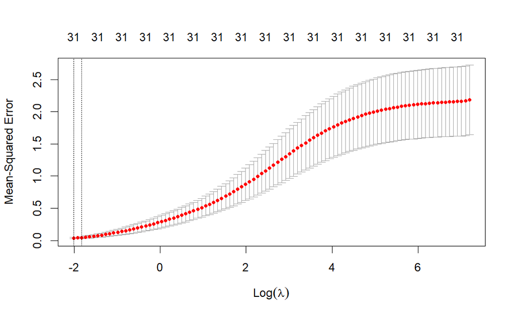

```r
mejor.lambda =sal.cv$lambda.min
mejor.lambda
```

```
[1] 0.133779
```

```r
log(mejor.lambda)
```

```
[1] -2.011566
```

```r
#hacer prediccion con el mejor lambda
coef(ridge.model)[,which(ridge.model$lambda==mejor.lambda)]
```

```
                  (Intercept)                           age
                -2.826285e-02                 -6.971972e-04
              positionForward            positionGoalkeeper
                 4.571784e-02                 -2.785250e-03
           positionMidfielder        minutes_played_overall
                 2.006507e-02                  3.567046e-05
          minutes_played_home           appearances_overall
                 1.277726e-04                 -1.474561e-03
             appearances_home                    goals_home
                -4.336702e-04                  8.003212e-01
                   goals_away               assists_overall
                 8.096496e-01                  1.214358e-02
                 assists_home                 penalty_goals
                 4.352718e-03                  1.706975e-01
               penalty_misses          clean_sheets_overall
                 2.200521e-01                  6.169437e-03
            clean_sheets_home              conceded_overall
                 5.825470e-03                 -2.061652e-04
                conceded_home          yellow_cards_overall
                -8.720942e-05                 -2.927927e-03
            red_cards_overall goals_involved_per_90_overall
                 7.281224e-03                  2.846747e-02
       assists_per_90_overall          goals_per_90_overall
                -7.414825e-02                  4.973895e-02
            goals_per_90_home             goals_per_90_away
                 5.353328e-01                  4.649615e-01
         min_per_goal_overall       conceded_per_90_overall
                 2.420381e-05                 -4.321692e-03
     min_per_conceded_overall                 min_per_match
                -2.911438e-04                  1.455120e-05
         min_per_card_overall          cards_per_90_overall
                 2.323486e-05                 -1.499813e-05
```

```r
pred=predict(ridge.model, s=mejor.lambda,newx = x.test.datos)
pred
```

```
               s1
1   -3.015995e-02
4   -2.474708e-02
18  -1.450747e-02
20  -4.904639e-03
21   5.411571e-02
25   2.148474e-01
35  -3.858447e-02
40   1.283666e-02
43   6.244116e+00
54  -4.153317e-02
60  -6.887701e-02
66   3.000821e+00
70  -5.677044e-02
72   1.035988e+00
```

[output cut: 113 more lines]

| RMSE | s1 |
| --- | --- |
| 0.1454653 | 0.9951767 |

Ahora se implementará el modelo de regresión LASSO

```r
x=model.matrix(goals_overall~.,train.datos)[,-1]
print(x)
```

```
    age positionForward positionGoalkeeper positionMidfielder minutes_played_overall
2    29               0                  0                  0                   1887
3    24               0                  0                  1                    536
5    20               0                  0                  1                     30
6    30               1                  0                  0                    520
7    20               0                  0                  0                     66
8    27               0                  1                  0                    406
9    23               0                  0                  0                   1073
10   17               0                  1                  0                      0
11   24               0                  0                  1                   1006
12   30               0                  0                  1                    348
13   30               1                  0                  0                    646
14   21               0                  0                  0                    104
15   27               0                  0                  0                    228
16   21               0                  0                  1                     61
```

[output cut: 250 more lines]

```r
#Para generar la variable dependiente
y=train.datos$goals_overall
print(y)
```

```
  [1]  3  2  0  0  0  0  0  0  1  0  2  0  0  0  1  0  3  0  0  1  0  4  0  0  0  2  0  6
 [29]  4  0  0  0  0  1  0  0  0  0  1  0  0  0  0  2  3  0  0  0  0  5  0  1  0  0  3  0
 [57]  1  0  0  1  0  0  0  0  0  1  0  0  0  0  0  0  0  6  0  0  1  3  0  0  0  0  0  4
 [85]  0  1  0  0  0  0  0  1  0  0  3  2  0  2  0  1  4  1  0  2  0  0  0  0  0  1  6  0
[113]  0  1  1  0  0 12  0  1  0  1  0  0  0  0  0  0  6  5  0  1  6  0  0  0  8  0  0  2
[141]  3  0  0  0  0  0  2  2  0  0  1  0  0  1  0  0  0  0  0  1  0  0  0  0  2  1  0  0
[169]  0  1  0  1  0  0  1  1  0  1  0  0  1  0  3  0  0  0  2  0  0  0  0  0  0  0  0  3
[197]  0  1  0  0  2  0  0  1  1  0  0  0  0  0  1  0  1  0  0  0  3  0  0  0  0  0  0  0
[225]  0  0  0  0  3  0  0  3  0  0  1  0  0  7  0  0  0  0  0  0  3  0  1  2  0  0  6  0
[253]  0  1  0  0  0  1  0  2  0  0  1  3  0  0  0  0  0  0  0  0  0  0  1  0  0  0  0  0
[281]  0  0  0  0  0  0  0  0  0  0  0  0  0  0  0  0  0  0  1  0  0  0  0  3  0  2  0  0
[309]  0  2  2  0  0  0  2  0  0  0  0  0  0  0  0  0  3  0  1  0  0  1  0  1  2  1  0  0
[337]  0  0  0  0  4  0  0  3  0  0  0  0  1  1  0  0  0  1  1  0  0  0  0  1  0  0  1  0
[365]  0  0  2  0  1  0  3  1  0  0  0  0  0  0  0  0  1  0  0  2  1  0  0  0  0 10  0  0
[393]  0 11  6  0  0  0  0  0  1  4  0  1  0  0  0  0  0  3  1  2  0  0  0  0  0  1  2  0
[421]  5  0  0  0  0  2  0  0  0  0  0  0  0  0  0  0  0  0  0  5  3  3  0  0  1  0  0  0
[449]  0  1  0  0  0  1  0  0  0  0  0  0  0  0  1  0  0  0  0  0  2  0  1  2  0  0  2  0
[477]  1  0  0  1  1  2  0  0  1  0  1  3  0  2  0  1  0  0  1  1  3  0  0  0  0  0  0  3
[505]  0  0  2  0  0  0
```

```r
lasso.model=glmnet(x,y,alpha =1)
dim(coef(lasso.model))
```

```
[1] 32 39
```

```r
Coeflasso=coef(lasso.model)
print(Coeflasso)
```

```
32 x 39 sparse Matrix of class "dgCMatrix"
```

```
  [[ suppressing 39 column names ‘s0’, ‘s1’, ‘s2’ ... ]]
  [[ suppressing 39 column names ‘s0’, ‘s1’, ‘s2’ ... ]]
```

```
(Intercept)            0.6686275 0.6199525 0.5756018 0.52446836 0.4778690 0.4354165
age                    .         .         .         .          .         .
positionForward        .         .         .         .          .         .
positionGoalkeeper     .         .         .         .          .         .
positionMidfielder     .         .         .         .          .         .
minutes_played_overall .         .         .         .          .         .
minutes_played_home    .         .         .         .          .         .
appearances_overall    .         .         .         .          .         .
appearances_home       .         .         .         .          .         .
goals_home             .         0.1241210 0.2372155 0.30500745 0.3667830 0.4230363
goals_away             .         .         .         0.08879182 0.1697176 0.2434776
assists_overall        .         .         .         .          .         .
assists_home           .         .         .         .          .         .

(Intercept)            0.3967353 0.3614904 0.3293766 0.3001157 0.2734542 0.2491613
age                    .         .         .         .         .         .
positionForward        .         .         .         .         .         .
positionGoalkeeper     .         .         .         .         .         .
positionMidfielder     .         .         .         .         .         .
minutes_played_overall .         .         .         .         .         .
minutes_played_home    .         .         .         .         .         .
appearances_overall    .         .         .         .         .         .
appearances_home       .         .         .         .         .         .
goals_home             0.4742922 0.5209946 0.5635481 0.6023213 0.6376500 0.6698402
goals_away             0.3106849 0.3719218 0.4277185 0.4785584 0.5248819 0.5670901
assists_overall        .         .         .         .         .         .
assists_home           .         .         .         .         .         .

(Intercept)            0.2270265 0.2068581 0.1884814 0.1717372 0.1564806 0.1425793
age                    .         .         .         .         .         .
positionForward        .         .         .         .         .         .
positionGoalkeeper     .         .         .         .         .         .
positionMidfielder     .         .         .         .         .         .
minutes_played_overall .         .         .         .         .         .
minutes_played_home    .         .         .         .         .         .
appearances_overall    .         .         .         .         .         .
appearances_home       .         .         .         .         .         .
goals_home             0.6991706 0.7258955 0.7502462 0.7724336 0.7926500 0.8110704
goals_away             0.6055486 0.6405906 0.6725195 0.7016120 0.7281199 0.7522730
assists_overall        .         .         .         .         .         .
```

[output cut: 46 more lines]

```
positionForward        .          .          .
positionGoalkeeper     .          .          .
positionMidfielder     .          .          .
minutes_played_overall .          .          .
minutes_played_home    .          .          .
appearances_overall    .          .          .
appearances_home       .          .          .
goals_home             0.96777350 0.97063641 0.9732450
goals_away             0.95768348 0.96144277 0.9648681
assists_overall        .          .          .
assists_home           .          .          .

 ..............................
 ........suppressing 7 rows in show(); maybe adjust 'options(max.print= *, width = *)'
 ..............................
```

```
  [[ suppressing 39 column names ‘s0’, ‘s1’, ‘s2’ ... ]]
```

```
red_cards_overall             . . . . . . . . . . . . . . . . . . . . . . . . . . . . .
goals_involved_per_90_overall . . . . . . . . . . . . . . . . . . . . . . . . . . . . .
assists_per_90_overall        . . . . . . . . . . . . . . . . . . . . . . . . . . . . .
goals_per_90_overall          . . . . . . . . . . . . . . . . . . . . . . . . . . . . .
goals_per_90_home             . . . . . . . . . . . . . . . . . . . . . . . . . . . . .
goals_per_90_away             . . . . . . . . . . . . . . . . . . . . . . . . . . . . .
min_per_goal_overall          . . . . . . . . . . . . . . . . . . . . . . . . . . . . .
conceded_per_90_overall       . . . . . . . . . . . . . . . . . . . . . . . . . . . . .
min_per_conceded_overall      . . . . . . . . . . . . . . . . . . . . . . . . . . . . .
min_per_match                 . . . . . . . . . . . . . . . . . . . . . . . . . . . . .
min_per_card_overall          . . . . . . . . . . . . . . . . . . . . . . . . . . . . .
cards_per_90_overall          . . . . . . . . . . . . . . . . . . . . . . . . . . . . .

red_cards_overall             . . . . . . . . . .
goals_involved_per_90_overall . . . . . . . . . .
assists_per_90_overall        . . . . . . . . . .
goals_per_90_overall          . . . . . . . . . .
goals_per_90_home             . . . . . . . . . .
goals_per_90_away             . . . . . . . . . .
min_per_goal_overall          . . . . . . . . . .
conceded_per_90_overall       . . . . . . . . . .
min_per_conceded_overall      . . . . . . . . . .
min_per_match                 . . . . . . . . . .
min_per_card_overall          . . . . . . . . . .
cards_per_90_overall          . . . . . . . . . .
```